# 10-2-kNN_regression

2025-02-17

### Code Accompanying *The Machine Learning Handbooks*, Volume I, Chapter 10

#### Book pdf is available on the GitHub repo: https://github.com/kjmazidi/Machine_Learning_3rd_edition

### Introduction

This notebook performs kNN regression on the Auto data in package ISLR. The [ISLR book](http://faculty.marshall.usc.edu/gareth-james/ISL/) is a really good and free resource for statistical learning in R. Two of the authors, Hastie and Tibshirani, also have a series of videos available [at this link](https://www.r-bloggers.com/in-depth-introduction-to-machine-learning-in-15-hours-of-expert-videos/)

Library imported: ISLR for kNN regression

```r
if (!require(ISLR)){
  install.packages("ISLR")
}
library("ISLR")
```

### Linear Regression baseline

This example uses the Auto data set in package ISLR. We convert the origin column to a factor.

```r
Auto$origin <- as.factor(Auto$origin)
str(Auto)
```

```
## 'data.frame':    392 obs. of  9 variables:
##  $ mpg         : num  18 15 18 16 17 15 14 14 14 15 ...
##  $ cylinders   : num  8 8 8 8 8 8 8 8 8 8 ...
##  $ displacement: num  307 350 318 304 302 429 454 440 455 390 ...
##  $ horsepower  : num  130 165 150 150 140 198 220 215 225 190 ...
##  $ weight      : num  3504 3693 3436 3433 3449 ...
##  $ acceleration: num  12 11.5 11 12 10.5 10 9 8.5 10 8.5 ...
##  $ year        : num  70 70 70 70 70 70 70 70 70 70 ...
##  $ origin      : Factor w/ 3 levels "1","2","3": 1 1 1 1 1 1 1 1 1 1 ...
##  $ name        : Factor w/ 304 levels "amc ambassador brougham",..: 49 36 231 14 161 141 54 223 241 2 ...
```

#### Train test split

Also remove the name column.

```r
set.seed(1234)
i <- sample(1:nrow(Auto), round(nrow(Auto)*0.8), replace=FALSE)
train <- Auto[i, -9]
test <- Auto[-i, -9]
```

Build a linear regression model with all predictors.

```r
lm1 <- lm(mpg ~., data=train)
summary(lm1)
```

```
##
## Call:
## lm(formula = mpg ~ ., data = train)
##
## Residuals:
##     Min      1Q  Median      3Q     Max
## -9.1240 -1.9819 -0.0147  1.7986 13.5953
##
## Coefficients:
##                Estimate Std. Error t value Pr(>|t|)
## (Intercept)  -1.828e+01  5.078e+00  -3.600 0.000371 ***
## cylinders    -6.165e-01  3.460e-01  -1.782 0.075789 .
## displacement  2.131e-02  8.123e-03   2.623 0.009147 **
## horsepower   -2.849e-02  1.430e-02  -1.992 0.047229 *
## weight       -5.768e-03  7.074e-04  -8.154 9.28e-15 ***
## acceleration -5.539e-02  1.056e-01  -0.524 0.600428
## year          8.010e-01  5.649e-02  14.180  < 2e-16 ***
## origin2       2.166e+00  6.102e-01   3.549 0.000448 ***
## origin3       2.852e+00  5.967e-01   4.779 2.74e-06 ***
## ---
## Signif. codes:  0 '***' 0.001 '**' 0.01 '*' 0.05 '.' 0.1 ' ' 1
##
## Residual standard error: 3.195 on 305 degrees of freedom
## Multiple R-squared:  0.8309, Adjusted R-squared:  0.8265
## F-statistic: 187.4 on 8 and 305 DF,  p-value: < 2.2e-16
```

#### Evaluate

```r
pred1 <- predict(lm1, newdata=test)
cor_lm1 <- cor(pred1, test$mpg)
mse_lm1 <- mean((pred1 - test$mpg)^2)
print(paste("cor=", cor_lm1))
```

```
## [1] "cor= 0.893368513146442"
```

```r
print(paste("mse=", mse_lm1))
```

```
## [1] "mse= 14.5943814943833"
```

These results aren’t bad. Let’s see what happens with kNN

### kNN for regression

Notice that origin needs to be an integer.

```r
library(caret)
train$origin <- as.integer(train$origin)
test$origin <- as.integer(test$origin)

# fit the model
fit <- knnreg(train[,2:8],train[,1],k=3)

# evaluate
pred2 <- predict(fit, test[,2:8])
cor_knn1 <- cor(pred2, test$mpg)
mse_knn1 <- mean((pred2 - test$mpg)^2)
print(paste("cor=", cor_knn1))
```

```
## [1] "cor= 0.878344750927036"
```

```r
print(paste("mse=", mse_knn1))
```

```
## [1] "mse= 17.029943019943"
```

The results for kNN weren’t quite as good as the linear regression model.

One reason might be that we didn’t scale the data. kNN will work better on scaled data.

### Scale the data

Notice we are scaling both train and test on the means and standard deviations of the training set. This is considered a best practice so that information about the test data doesn’t leak into the scaling.

```r
train_scaled <- train[, 2:8]  # omit name and don't scale mpg
means <- sapply(train_scaled, mean)
stdvs <- sapply(train_scaled, sd)
train_scaled <- scale(train_scaled, center=means, scale=stdvs)
test_scaled <- scale(test[, 2:8], center=means, scale=stdvs)
```

### kNN on scaled data

```r
fit <- knnreg(train_scaled, train$mpg, k=3)
pred3 <- predict(fit, test_scaled)
cor_knn2 <- cor(pred3, test$mpg)
mse_knn2 <- mean((pred3 - test$mpg)^2)
print(paste("cor=", cor_knn2))
```

```
## [1] "cor= 0.905223016978903"
```

```r
print(paste("mse=", mse_knn2))
```

```
## [1] "mse= 14.4425925925926"
```

```r
print(paste("rmse=", sqrt(mse_knn2)))
```

```
## [1] "rmse= 3.80034111529381"
```

Wow. Now kNN has a higher correlation than linear regression and a lower mse.

### Find the best k

Try various values of k and plot the results.

```r
cor_k <- rep(0, 20)
mse_k <- rep(0, 20)
i <- 1
for (k in seq(1, 39, 2)){
  fit_k <- knnreg(train_scaled,train$mpg, k=k)
  pred_k <- predict(fit_k, test_scaled)
  cor_k[i] <- cor(pred_k, test$mpg)
  mse_k[i] <- mean((pred_k - test$mpg)^2)
  print(paste("k=", k, cor_k[i], mse_k[i]))
  i <- i + 1
}
```

```
## [1] "k= 1 0.928963796663712 10.4517948717949"
## [1] "k= 3 0.905223016978903 14.4425925925926"
## [1] "k= 5 0.916071827066313 12.6385384615385"
## [1] "k= 7 0.923579467849894 11.6815096807954"
## [1] "k= 9 0.922319734386922 11.9541389680279"
## [1] "k= 11 0.92092994977216 12.2067524899343"
## [1] "k= 13 0.917489418697034 12.4518047337278"
## [1] "k= 15 0.91065328097819 13.2510102564103"
## [1] "k= 17 0.908829459455411 13.7260651228817"
## [1] "k= 19 0.90768560899354 13.7695333475389"
## [1] "k= 21 0.904407122181182 14.2233957528763"
## [1] "k= 23 0.905769718187576 14.0201846735495"
## [1] "k= 25 0.906027349563838 13.9550775384615"
## [1] "k= 27 0.904524090335153 14.14520347508"
## [1] "k= 29 0.90132884515121 14.4494716317571"
## [1] "k= 31 0.90060956863369 14.5867511139572"
## [1] "k= 33 0.896938247996035 15.0150978087511"
## [1] "k= 35 0.894975428658597 15.3155299843014"
## [1] "k= 37 0.894818579095498 15.3374458242026"
## [1] "k= 39 0.8953275515944 15.3366590805644"
```

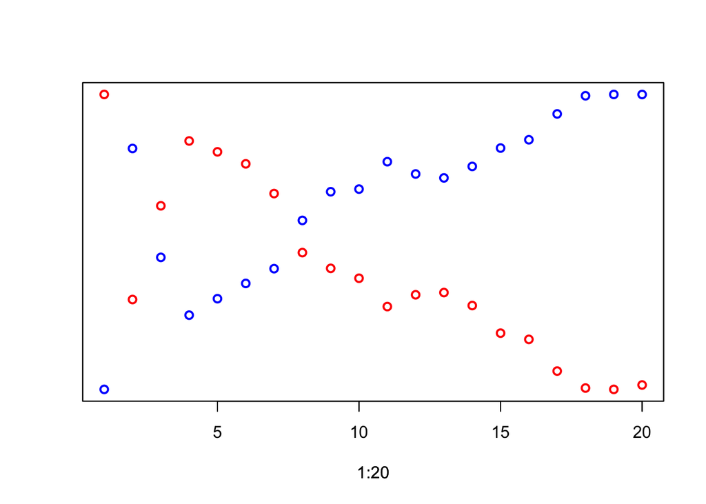

```r
plot(1:20, cor_k, lwd=2, col='red', ylab="", yaxt='n')
par(new=TRUE)
plot(1:20, mse_k, lwd=2, col='blue', labels=FALSE, ylab="", yaxt='n')
```

We can visually see that at k=1 the red correlation is highest and the blue mse is lowest.

```r
which.min(mse_k)
```

```
## [1] 1
```

```r
which.max(cor_k)
```

```
## [1] 1
```

### kNN with k=1

The results were better with k=1.

```r
fit <- knnreg(train_scaled, train$mpg, k=1)
pred4 <- predict(fit, test_scaled)
cor_knn3 <- cor(pred4, test$mpg)
mse_knn3 <- mean((pred4 - test$mpg)^2)
print(paste("cor=", cor_knn3))
```

```
## [1] "cor= 0.928963796663712"
```

```r
print(paste("mse=", mse_knn3))
```

```
## [1] "mse= 10.4517948717949"
```